# Basic Statistical Summaries

Let us first explore the statistical summaries for the various data points in our dataset.

```r
summary(data_cleaned)
```

```
##        id                 type                boatClass
##  Min.   : 444913   power    :18610   power-pontoon :4038
##  1st Qu.:6895201   sail     :  254   power-bowrider:1342
##  Median :7061616   unpowered:   39   power-bass    :1291
##  Mean   :6947263                     power-center  :1209
##  3rd Qu.:7179152                     power-cruiser :1158
##  Max.   :7271336                     power-aluminum:1014
##                                      (Other)       :8851
##            make                         model            year
##  Tracker     : 1894   Z18                  :   93   Min.   :1910
##  Sun Tracker :  907   Pro Team 175 TXW     :   91   1st Qu.:2011
##  Bennington  :  843   Party Barge 22 DLX   :   84   Median :2019
##  Sea Ray     :  728   Pro Guide V-16 SC    :   74   Mean   :2013
##  Yamaha Boats:  728   Pro Guide V-175 Combo:   74   3rd Qu.:2019
##  Nitro       :  428   (Other)              :18452   Max.   :2020
##  (Other)     :13375   NA's                 :   35
##  condition      length_ft        beam_ft         dryWeight_lb
##  new :11189   Min.   :  1.0   Min.   :   0.08   Min.   :     8
##  used: 7714   1st Qu.: 18.0   1st Qu.:   7.83   1st Qu.:  1175
##               Median : 21.0   Median :   8.50   Median :  2001
##               Mean   : 23.8   Mean   :  16.20   Mean   :  4754
##               3rd Qu.: 25.0   3rd Qu.:   9.00   3rd Qu.:  3375
##               Max.   :375.0   Max.   :1311.00   Max.   :440000
##                               NA's   :6504      NA's   :11809
##      hullMaterial      fuelType      numEngines      totalHP
##  fiberglass:8148   diesel  : 924   Min.   :0.00   Min.   :   0.0
##  other     :5304   electric:  13   1st Qu.:1.00   1st Qu.:   0.0
##  aluminum  :5152   gasoline:6359   Median :1.00   Median :   0.0
##  composite : 159   other   :8655   Mean   :1.07   Mean   : 112.8
##  wood      :  63   NA's    :2952   3rd Qu.:1.00   3rd Qu.: 115.0
##  steel     :  25                   Max.   :4.00   Max.   :7200.0
##  (Other)   :  52                                  NA's   :848
##  maxEngineYear   minEngineYear            engineCategory
##  Min.   :1938    Min.   :1938    outboard        : 4876
##  1st Qu.:2001    1st Qu.:2001    inboard         : 1401
##  Median :2012    Median :2012    inboard-outboard:  950
##  Mean   :2008    Mean   :2008    outboard-4s     :  865
##  3rd Qu.:2019    3rd Qu.:2019    other           :  138
##  Max.   :2020    Max.   :2020    (Other)         :  180
##  NA's   :16698   NA's   :16729   NA's            :10493
##      price              sellerId             city           state
##  Min.   :5.000e+02   Min.   :  1003   Red Wing :  598   FL     :2916
##  1st Qu.:1.926e+04   1st Qu.: 10550   Rochester:  571   MN     :1728
##  Median :3.420e+04   Median : 34482   Wayzata  :  503   MI     :1563
##  Mean   :6.471e+05   Mean   : 49892   Kingston :  376   TX     :1203
##  3rd Qu.:5.783e+04   3rd Qu.: 53226   Mecosta  :  363   WI     :1189
##  Max.   :1.000e+10   Max.   :269557   (Other)  :16436   OK     : 905
##                                       NA's     :   56   (Other):9399
##       zip           created_date   created_month     created_year
##  70072  : 268   2019-08-05:  545   Min.   : 1.000   Min.   :2003
##  28560  : 183   2019-08-23:  348   1st Qu.: 5.000   1st Qu.:2018
##  53072  : 171   2019-07-30:  339   Median : 8.000   Median :2019
##  54904  : 119   2019-04-17:  311   Mean   : 6.946   Mean   :2019
##  48045  : 110   2019-10-22:  227   3rd Qu.: 9.000   3rd Qu.:2019
##  (Other):9364   2019-10-03:  225   Max.   :12.000   Max.   :2019
##  NA's   :8688   (Other)   :16908
```

From above summary statistics, we know that the columns `type`, `boatClass`, `make`, `model`, `condition`, `hullMaterial`, `fuelType`, `engineCategory`, `city`,`state`, `zip` are text based categorical variables. `price`, `bean_ft`, `length_ft`, `total_hp` are continuous numeric variables. `year`,`created_year`, `created_month`, `numEngines` are numeric categorical variables and `created_date` is a date variable.

## Price variable Anamolies

It is to be noted that the price includes prices for both new and used boats. It is important to keep this in mind when making statistical inferences on the price variable.

### Price Plots - All Boats

**Histogram**

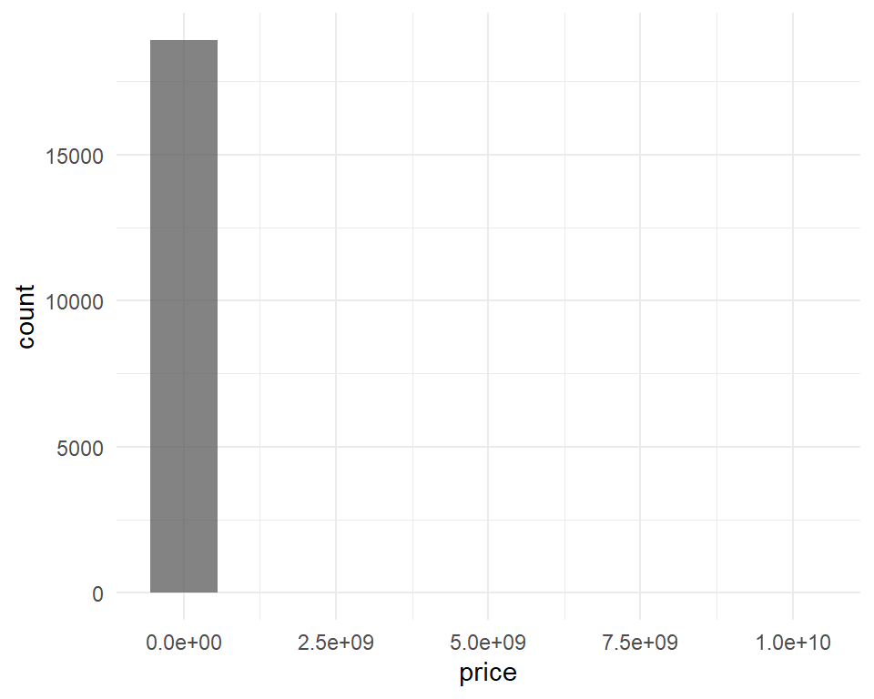

**QQ Plot**

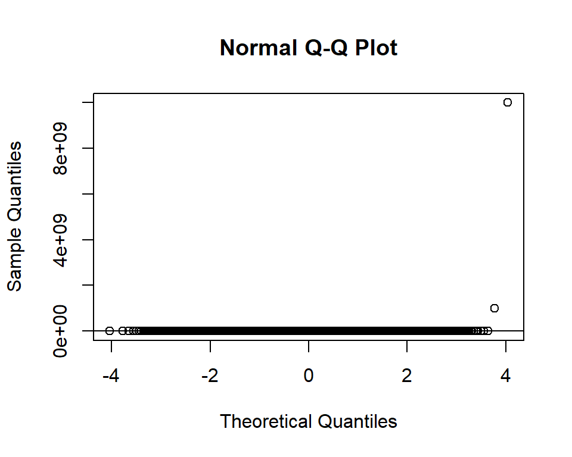

As evidenced by the plots above we have a very skewed dataset. One way to mitigate this is to use a log scale on the price variable. This reduces our intuitive understanding of the prices, but overall gives us a much better variable for building our models.

### Log Price normality verification.

Let us verify if the `log(price)` is fairly normal.

**Histogram**

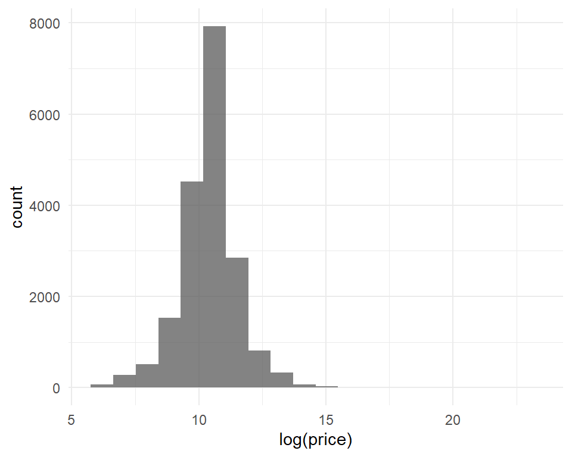

**QQ Plot**

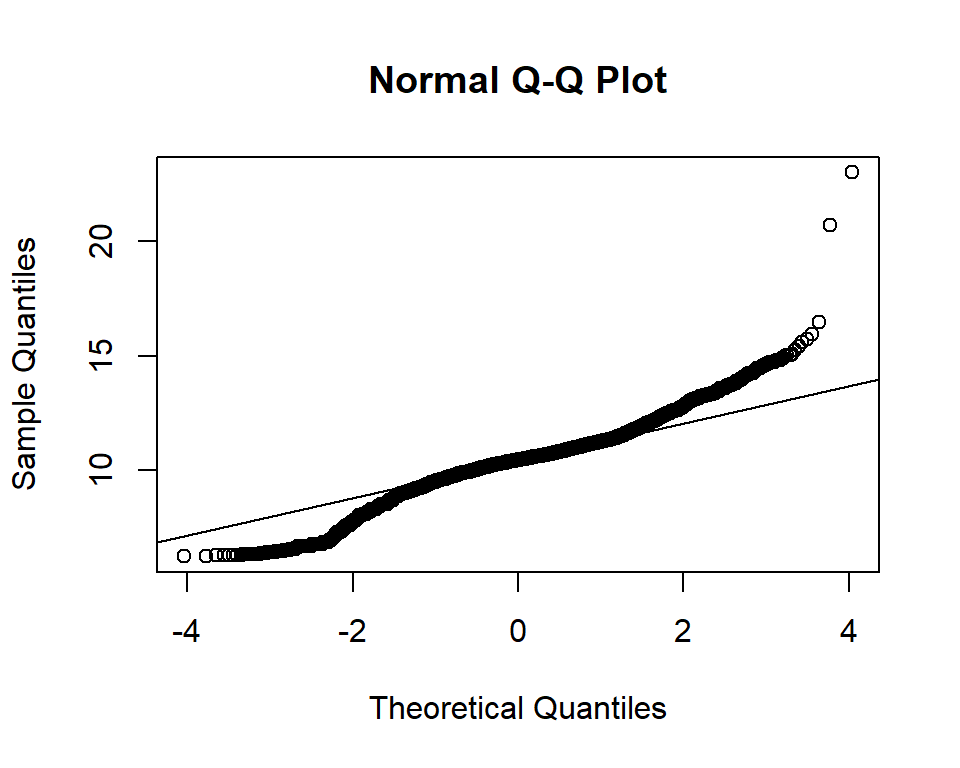

The price variable is fairly normal in the Inter quartile range (-2,2) but still has outliers in the sections beyond this range.

We can get a better look at the outliers using a box plot.

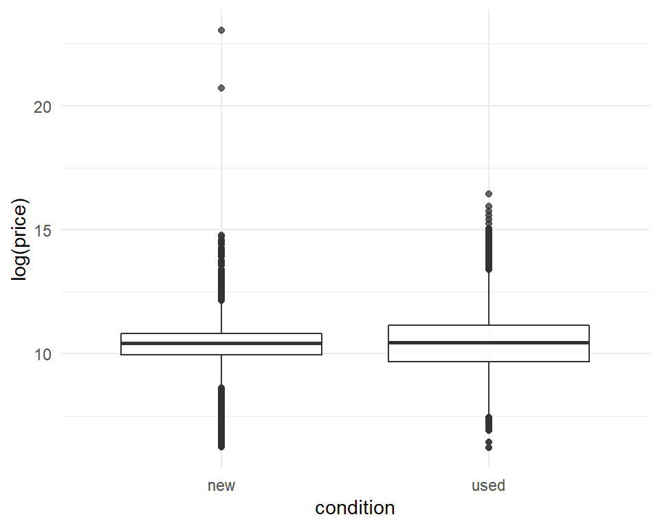

These outliers can cause significant hinderences to model building. We need to make a decision on if it is possible to eliminate some of these outliers. To do this we will have to take a closer look at the outliers.

## Outliers Removal

We can define outliers in multiple ways, we can use IQR and set a range on the IQR (usually $\pm 1.5$ ) outside which lie the outliers. However, since we can make certan assumptions on the data, we can set a hard bounds on the price to determine outliers. For the pueposes of this analysis we will define a lower bound on price of 5,000 and an upper bound of 200,000. Anything outside this limit is considered an outlier.

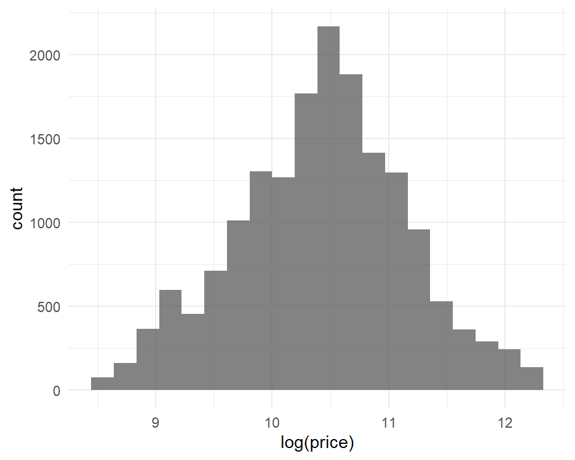

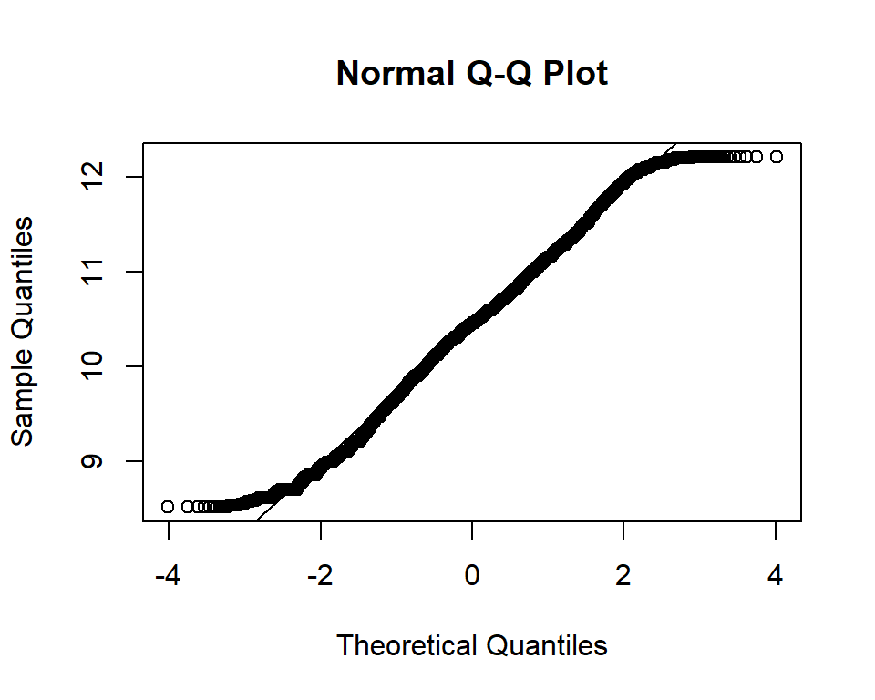

# Graphical Visualizations

## Number of listings by various categories

### State

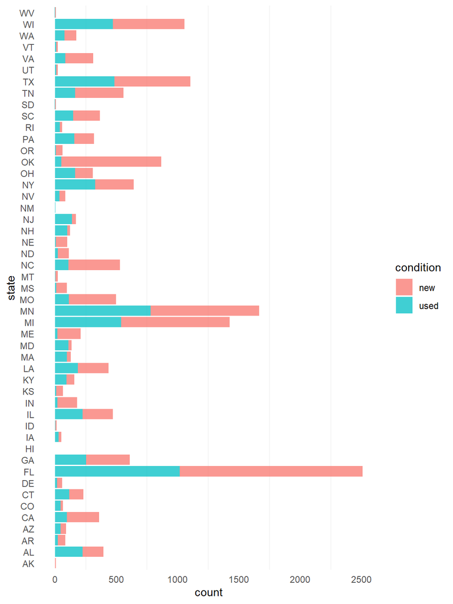

### Fuel Type

Fuel Type has the following categories:

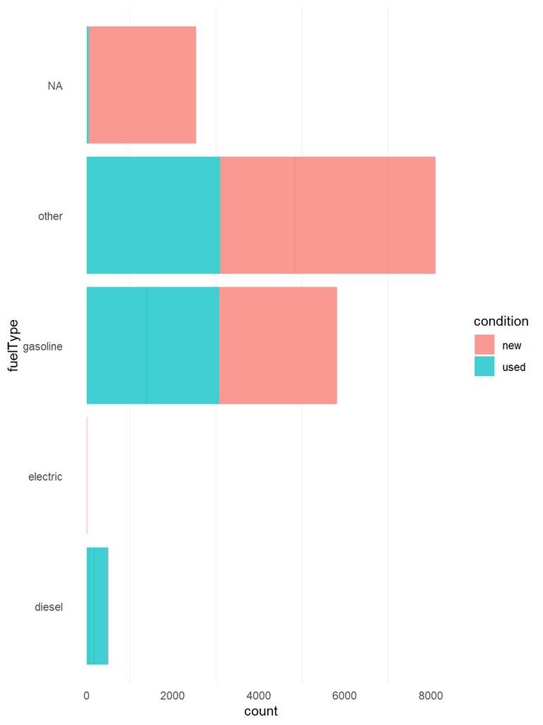

### Adding a Seller Volumn Column to the data_cleaned file

To perform analysis on the seller volumn column, we will add a count of number of listings by `sellerID`. To do this we can employ the `data.table` library.

```r
library(data.table)
temp_table <- data.table(data_cleaned)
data_cleaned <- temp_table[,sellerVolume:=.N,by=sellerId]
```